# Proje Rapor : Ahmet Yildirim 210401084.

ahmet yildirim

2024-01-17

# Q1 : Problem Tanımı

Şirketimiz **Yıldırım Bilişim**. Projemiz kişiye özel egzersiz programı uygulamasıdır.

# Q2 : Proje Amacı

Amacımız son dönemlerde ülkemizde artan ve bilimsel veriler ışığında gelecekte daha da artacağı tahmin edilen obezite, diyabet, tansiyon, postür bozuklukları, kifoz, skolyoz, vb. hastalıklara karşı yardımcı bir tedavi oluşturmaktır. Bu hastalıkların artacağını öngördüğümüz için uygulamaya talebin yüksek olacağını düşünüyoruz, aynı zamanda ülkemiz insanına da yararlı olmak istiyoruz.

Uygulamada kişinin sahip olduğu hastalık ve diğer bilgiler (yaş, cinsiyet, boy, kilo, vb.) baz alınarak özel bir antrenman programı oluşturulacaktır. Oluşturulan bu antrenman programının hedefi kişinin hayat kalitesini arttırmak, sahip olduğu hastalığı mümkün olduğu ölçüde tedavi etmek ve kişiye spor alışkanlığı kazandırmaktır.

# Q3 : Veri seti keşifsel analizi

# Veri seti boyutları

- Satır sayısı: 1326
- Sütun sayısı: 6
  1. sütunda vücudun hangi bölgesini kullanarak egzersizin yapıldığı,
  2. sütunda hangi ekipmanla egzersizin yapıldığı,
  3. sütunda egzersizin yapılışın gif olarak gösterimi,
  4. sütunda egzersizin id numarası,
  5. sütunda egzersizin ismi,
  6. sütunda egzersizin vücutta etki ettiği kas grubunun ismi verilmiş.

  Biz projemizi hazırlarken tüm sütunları kullandık. Herhangi bir sütunu çıkarmaya veya eklemeye gerek duymadık. Veri setimizdeki tüm sutunlar karakter veri tipiydi. Projenin ilerleyen kısımlarında bazı sütunları gerektiğinde faktör ve nümerik veri tiplerine çevirdik. Veri setinde anlamsız veya yanlış bir veri yoktu.

Veri setininin genel görünümü aşağıda verilmiştir. Bu veri seti üzerinde çalıştık. Fikir sahibi olmak için inceleyebilirsiniz.

| bodyPart | equipment | gifUrl | id | name | target |
| --- | --- | --- | --- | --- | --- |
| waist | body weight | http://d205bpvrqc9yn1.cloudfront.net/0001.gif | 0001 | 3/4 sit-up | abs |
| waist | body weight | http://d205bpvrqc9yn1.cloudfront.net/0002.gif | 0002 | 45° side bend | abs |
| waist | body weight | http://d205bpvrqc9yn1.cloudfront.net/0003.gif | 0003 | air bike | abs |
| upper legs | body weight | http://d205bpvrqc9yn1.cloudfront.net/1512.gif | 1512 | all fours squad stretch | quads |
| waist | body weight | http://d205bpvrqc9yn1.cloudfront.net/0006.gif | 0006 | alternate heel touchers | abs |
| back | cable | http://d205bpvrqc9yn1.cloudfront.net/0007.gif | 0007 | alternate lateral pulldown | lats |
| back | body weight | http://d205bpvrqc9yn1.cloudfront.net/3293.gif | 3293 | archer pull up | lats |
| chest | body weight | http://d205bpvrqc9yn1.cloudfront.net/3294.gif | 3294 | archer push up | pectorals |
| waist | body weight | http://d205bpvrqc9yn1.cloudfront.net/2355.gif | 2355 | arm slingers hanging bent knee legs | abs |
| waist | body weight | http://d205bpvrqc9yn1.cloudfront.net/2333.gif | 2333 | arm slingers hanging straight legs | abs |

[output cut: 1316 more lines]

Uygulamamızda kullanıcıya özel filtreleme sistemleri kullanıyoruz ve en uygun egzersiz programını sunuyoruz. Karşınızda küçük bir filtreleme örneği, yanlızca vücut ağırlığıyla yapılacak egzersizler:

| bodyPart | equipment | gifUrl | id | name | target |
| --- | --- | --- | --- | --- | --- |
| waist | body weight | http://d205bpvrqc9yn1.cloudfront.net/0001.gif | 0001 | 3/4 sit-up | abs |
| waist | body weight | http://d205bpvrqc9yn1.cloudfront.net/0002.gif | 0002 | 45° side bend | abs |
| waist | body weight | http://d205bpvrqc9yn1.cloudfront.net/0003.gif | 0003 | air bike | abs |
| upper legs | body weight | http://d205bpvrqc9yn1.cloudfront.net/1512.gif | 1512 | all fours squad stretch | quads |
| waist | body weight | http://d205bpvrqc9yn1.cloudfront.net/0006.gif | 0006 | alternate heel touchers | abs |
| back | body weight | http://d205bpvrqc9yn1.cloudfront.net/3293.gif | 3293 | archer pull up | lats |
| chest | body weight | http://d205bpvrqc9yn1.cloudfront.net/3294.gif | 3294 | archer push up | pectorals |
| waist | body weight | http://d205bpvrqc9yn1.cloudfront.net/2355.gif | 2355 | arm slingers hanging bent knee legs | abs |
| waist | body weight | http://d205bpvrqc9yn1.cloudfront.net/2333.gif | 2333 | arm slingers hanging straight legs | abs |
| upper legs | body weight | http://d205bpvrqc9yn1.cloudfront.net/3214.gif | 3214 | arms apart circular toe touch (male) | glutes |

[output cut: 314 more lines]

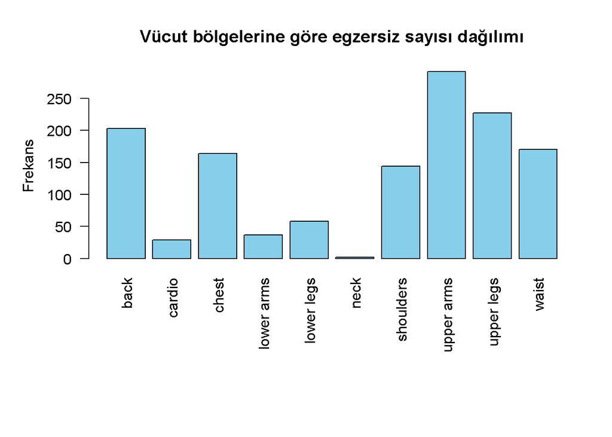

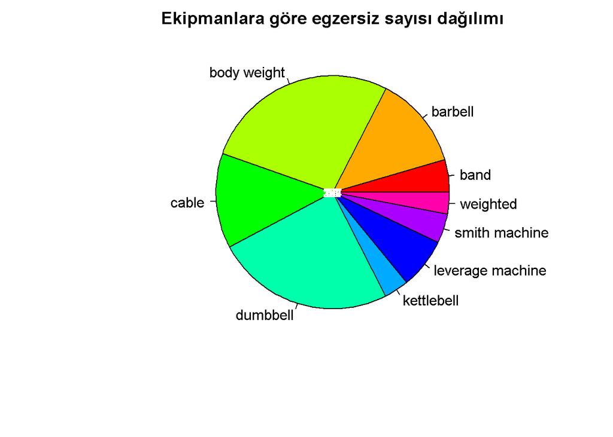

Vücuttaki hedeflenen kas bölgelerine göre egzersiz sayılarını da bir tablo haline getirdik. Zayıf olduğunuz kasları tespit edip güçlendirme egzersizleri de öneriyoruz.

| Hedef Kas Grubu | Toplam Egzersiz Sayısı |
| --- | --- |
| abductors | 5 |
| abs | 170 |
| adductors | 6 |
| biceps | 151 |
| calves | 58 |
| cardiovascular system | 29 |
| delts | 144 |
| forearms | 37 |
| glutes | 144 |
| hamstrings | 28 |

[output cut: 9 more lines]

# Q4: Veri seti ön işlemesi

Görüldüğü üzere zaten veri setinde NA değer yoktu. 10 adet farklı vücut bölgesi üzerinde, 28 farklı ekipman kullanarak kullanıcılarımız için egzersiz programları hazırladık.

```
##   NAs_before NAs_after unique_values_bodyPart unique_values_equipment
## 1          0         0                     10                      28
```

# Q5 : Veri mühendisliği

Veri setinin istatistiksel özetini inceleyebilirsiniz:

```
##        bodyPart    equipment            gifUrl               id
##  upper arms:292   Length:1326        Length:1326        Length:1326
##  upper legs:227   Class :character   Class :character   Class :character
##  back      :203   Mode  :character   Mode  :character   Mode  :character
##  waist     :170
##  chest     :164
##  shoulders :144
##  (Other)   :126
##      name              target
##  Length:1326        Length:1326
##  Class :character   Class :character
##  Mode  :character   Mode  :character
##
##
##
##
```

Bu bölümde spesifik bilgiler hazırladık.

Aşağıda vücut bölgesine özel, ekipman kullanım sıklığını gösteren bir grafiği inceleyebilirsiniz:

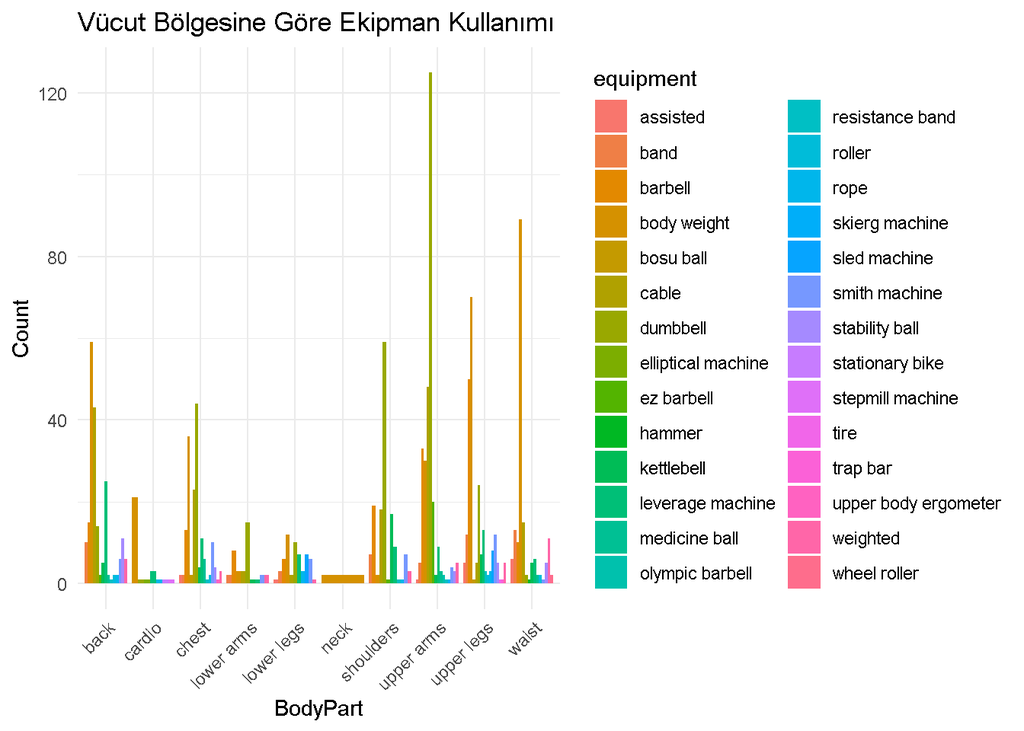

Bu grafik ise , vücut bölgelerine göre hedeflenen kasların isimlerini içermektedir.

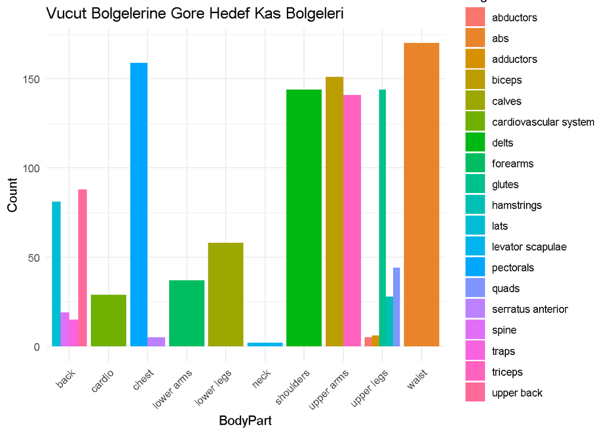